# Sensitivity analysis

## Basic ODE integration

We will use `solve_ivp` function from SciPy for solving ODEs. It supports:

- Initial value problems (IVPs)
- Stiff and non-stiff problems
- Various integration methods: `RK45`, `RK23`, `Radau`, `BDF`, `LSODA`

It requires:

- A function that defines your differential equation.
- The time range over which you want to solve the ODE.
- The starting value of your system — a list or array of initial conditions.
- The integration method.
- A NumPy array of time points at which to store the solution. If not set, it only returns a few key points.

Let's try to solve the following differential equation with parameter $k=0.4$ and initial condition $y_{0} = 6$:

$$ \frac{dy}{dt} = -ky $$

```python
import numpy as np
from scipy.integrate import solve_ivp
import matplotlib.pyplot as plt

# define the ODE
def model(t, y):    # must always take two arguments: time t and state y
    k = 0.4
    return -k * y

# time interval and initial condition
t_span = (0, 30)
y0 = [6]

# define time points at which to evaluate the solution
t_eval = np.linspace(t_span[0], t_span[1], 100)

# solve the ODE
sol = solve_ivp(model, t_span, y0, method='RK45', t_eval=t_eval)
```

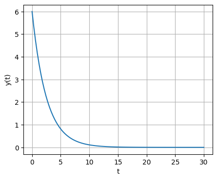

```python
# plot
plt.figure(figsize=(5,4))
plt.plot(sol.t, sol.y[0])
plt.xlabel('t')
plt.ylabel('y(t)')
plt.grid(True)
plt.show()
```

An optional input of `solve_ivp` function is `args` that allows additional information to be passed into the model function.

The `args` input is a tuple sequence of values.

```python
def model(t, y, k):
    dydt = -k*y
    return dydt
```

```python
k = 0.1
sol1 = solve_ivp(model, t_span, y0, args=(k,), method='RK45', t_eval=t_eval)

k = 0.3
sol2 = solve_ivp(model, t_span, y0, args=(k,), method='RK45', t_eval=t_eval)

k = 0.6
sol3 = solve_ivp(model, t_span, y0, args=(k,), method='RK45', t_eval=t_eval)
```

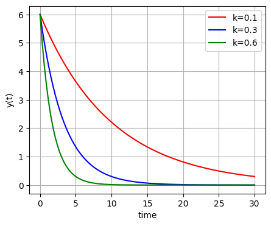

```python
plt.figure(figsize=(5,4))
plt.plot(sol1.t, sol1.y[0], 'r', label='k=0.1')
plt.plot(sol2.t, sol2.y[0], 'b', label='k=0.3')
plt.plot(sol3.t, sol3.y[0], 'g', label='k=0.6')
plt.xlabel('time')
plt.ylabel('y(t)')
plt.grid(True)
plt.legend(loc='best')
plt.show()
```

## Logistic growth

The logistic growth is a classic model used to describe how a population grows in an environment with **limited resources**.

$$ \frac{dy}{dt} = ry\left( 1 - \frac{y}{k} \right)$$

where $y(t)$ is the size of the population at time $t$, $r$ is the growth rate and $k$ is the carrying capacity, that is the number of people, other living organisms, or crops that a region can support without environmental degradation.

```python
def logistic(t, y, r, k):
    dydt = r*y*(1 - y/k)
    return dydt
```

```python
# initial condition
y0 = [10]

# time interval
t_span = (0, 120)

# time points at which to evaluate the solution
t_eval = np.linspace(t_span[0], t_span[1], 200)

# parameters
r = 0.1
k = 1500

# solve ODE
sol = solve_ivp(logistic, t_span, y0, args=(r, k), method='RK45',
                t_eval=t_eval)
```

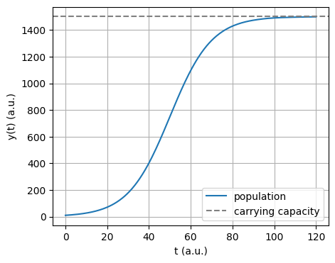

```python
# plot
plt.figure(figsize=(5,4))
plt.plot(sol.t, sol.y[0], label='population')
plt.xlabel('t (a.u.)')
plt.ylabel('y(t) (a.u.)')
plt.grid(True)
plt.axhline(k, label='carrying capacity', color='gray', linestyle='--')
plt.legend(loc='best')
plt.show()
```

Sensitivity analysis for ODEs helps you understand how sensitive the solution of an ODE is to changes in its parameters. This is useful in modeling and simulations, especially in contexts where parameters are often estimated or uncertain.

It is convenient to transform the result of the integration in a `pandas` dataframe.

This allows us to use it for better visualization through `seaborn`.

```python
import pandas as pd

def create_df(result, columns, **other_info):
    df = pd.DataFrame(result, columns=columns)
    for key, value in other_info.items():
        df[key] = value
    return df
```

```python
create_df(sol.y[0], ['population'], r=r, k=k, time=sol.t).head()
```

|  | population | r | k | time |
| --- | --- | --- | --- | --- |
| 0 | 10.000000 | 0.1 | 1500 | 0.000000 |
| 1 | 10.617168 | 0.1 | 1500 | 0.603015 |
| 2 | 11.272137 | 0.1 | 1500 | 1.206030 |
| 3 | 11.967188 | 0.1 | 1500 | 1.809045 |
| 4 | 12.704818 | 0.1 | 1500 | 2.412060 |

```python
# randomly generate 50 normally distributed values of r
rates = np.random.normal(r, 0.02, 50)

results = []
idx = 0
for ri in rates:
    sols = solve_ivp(logistic, t_span, y0, args=(ri, k), method='RK45',
                     t_eval=t_eval)
    ys_df = create_df(sols.y[0], ['population'], r=ri, k=k, time=sols.t,
                      simulation_run=idx)
    results.append(ys_df)
    idx = idx + 1
results = pd.concat(results, ignore_index=True)
```

```python
results
```

|  | population | r | k | time | simulation_run |
| --- | --- | --- | --- | --- | --- |
| 0 | 10.000000 | 0.067631 | 1500 | 0.000000 | 0 |
| 1 | 10.413363 | 0.067631 | 1500 | 0.603015 | 0 |
| 2 | 10.843689 | 0.067631 | 1500 | 1.206030 | 0 |
| 3 | 11.291664 | 0.067631 | 1500 | 1.809045 | 0 |
| 4 | 11.758028 | 0.067631 | 1500 | 2.412060 | 0 |
| ... | ... | ... | ... | ... | ... |
| 9995 | 1496.646332 | 0.094852 | 1500 | 117.587940 | 49 |
| 9996 | 1496.832211 | 0.094852 | 1500 | 118.190955 | 49 |
| 9997 | 1497.007796 | 0.094852 | 1500 | 118.793970 | 49 |
| 9998 | 1497.173694 | 0.094852 | 1500 | 119.396985 | 49 |
| 9999 | 1497.330480 | 0.094852 | 1500 | 120.000000 | 49 |

10000 rows × 5 columns

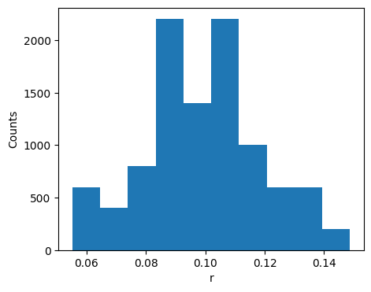

```python
plt.figure(figsize=(5,4))
plt.hist(results['r'], bins=10)
plt.ylabel('Counts')
plt.xlabel('r')
plt.show()
```

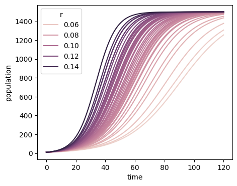

```python
import seaborn as sns

plt.figure(figsize=(5,4))
sns.lineplot(x="time", y="population", data=results, hue='r',
             estimator=None, units='simulation_run')
plt.show()
```

```python
# randomly generate 50 normally distributed values of k
capacities = np.random.normal(k, 100, 50)

results = []
idx = 0
for ci in capacities:
    sols = solve_ivp(logistic, t_span, y0, args=(r, ci), method='RK45',
                     t_eval=t_eval)
    ys_df = create_df(sols.y[0], ['population'], r=r, k=ci, time=sols.t,
                      simulation_run=idx)
    results.append(ys_df)
    idx = idx + 1
results = pd.concat(results, ignore_index=True)
```

```python
results
```

|  | population | r | k | time | simulation_run |
| --- | --- | --- | --- | --- | --- |
| 0 | 10.000000 | 0.1 | 1547.834633 | 0.000000 | 0 |
| 1 | 10.617304 | 0.1 | 1547.834633 | 0.603015 | 0 |
| 2 | 11.272435 | 0.1 | 1547.834633 | 1.206030 | 0 |
| 3 | 11.967676 | 0.1 | 1547.834633 | 1.809045 | 0 |
| 4 | 12.705534 | 0.1 | 1547.834633 | 2.412060 | 0 |
| ... | ... | ... | ... | ... | ... |
| 9995 | 1586.542453 | 0.1 | 1588.606234 | 117.587940 | 49 |
| 9996 | 1586.661951 | 0.1 | 1588.606234 | 118.190955 | 49 |
| 9997 | 1586.774591 | 0.1 | 1588.606234 | 118.793970 | 49 |
| 9998 | 1586.880928 | 0.1 | 1588.606234 | 119.396985 | 49 |
| 9999 | 1586.981503 | 0.1 | 1588.606234 | 120.000000 | 49 |

10000 rows × 5 columns

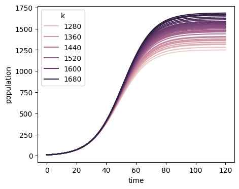

```python
plt.figure(figsize=(5,4))
sns.lineplot(x="time", y="population", data=results, hue='k',
             estimator=None, units='simulation_run')
plt.show()
```

## Sampling with noise

Sampling with noise is a powerful approach for understanding how measurement noise or uncertainty in the data affects parameter estimation in models like ODEs.

This can be done by:

- Introducing noise to the model (e.g., by adding Gaussian noise).
- Fitting the model to these noisy data points.
- Observing the covariation between the parameters after fitting the model, or how the fitted parameters change when there is noise in the data.

Let's consider the logistic growth model.

```python
def logistic(t, y, r, k):
    dydt = r*y*(1 - y/k)
    return dydt
```

```python
# initial condition
y0 = [0.1]

# time interval
t_span = (0, 1)

# time points at which to evaluate the solution
t_eval = np.linspace(t_span[0], t_span[1], 100)

# parameters
r = 10
k = 1

# solve ODE
sol = solve_ivp(logistic, t_span, y0, args=(r, k), method='RK45',
                t_eval=t_eval)
```

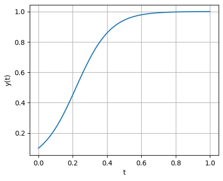

```python
plt.figure(figsize=(5,4))
plt.plot(sol.t, sol.y[0])
plt.xlabel('t')
plt.ylabel('y(t)')
plt.grid(True)
plt.show()
```

Let's add gaussian noise to our system.

To this end, we can use the `rvs` function from `scipy.stats`.

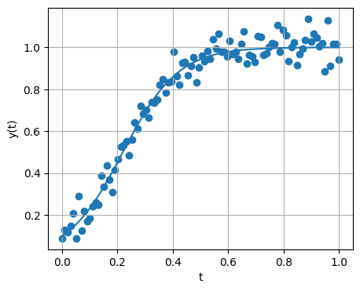

```python
import scipy.stats as st

y_hat_normal = st.norm.rvs(loc=sol.y[0], scale=0.05)

plt.figure(figsize=(5,4))
plt.plot(sol.t, sol.y[0])
plt.scatter(sol.t, y_hat_normal)
plt.xlabel('t')
plt.ylabel('y(t)')
plt.grid(True)
plt.show()
```

## Fitting procedure

To fit the model to these noisy data points, we will use the `curve_fit` function from `scipy.optimize`, that will give us an estimate of the parameters and their correlations.

To do this, it takes a function that, given the x values and a set of parameters, it gives the prediction.

First of all, let's see how it works in the simple case of a linear regression.

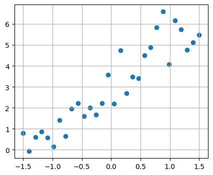

```python
from scipy.optimize import curve_fit

x = np.linspace(-1.5, 1.5, 30)
y = 2*x + 3
y_noisy = st.norm.rvs(loc=y, scale=0.8)

plt.figure(figsize=(5,4))
plt.scatter(x, y_noisy)
plt.grid(True)
plt.show()
```

```python
def linear_fit(xdata, m, q):
    return m*xdata + q

p_avg, p_cov = curve_fit(linear_fit, x, y_noisy, p0=[1, 0])
```

```python
p_avg
```

```
array([2.04457599, 2.99999716])
```

```python
p_cov
```

```
array([[ 2.4724775e-02, -2.0025130e-11],
       [-2.0025130e-11,  1.9822449e-02]])
```

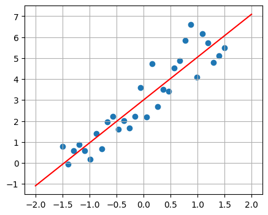

```python
x_values = np.linspace(-2, 2, 51)
y_hat = linear_fit(x_values, *p_avg)

plt.figure(figsize=(5,4))
plt.scatter(x, y_noisy)
plt.plot(x_values, y_hat, 'r')
plt.grid(True)
plt.show()
```

## How to visualize uncertainty?

- normal sampling
- 95% quantiles representation

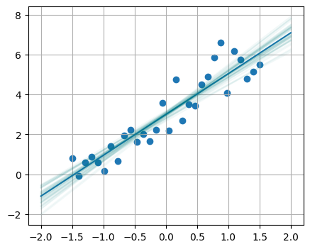

```python
p_seq = st.multivariate_normal.rvs(mean=p_avg, cov=p_cov, size=50)
x_base = np.linspace(-2, 2, 51)
y_hat = linear_fit(x_base, *p_avg)

plt.figure(figsize=(5,4))
plt.scatter(x, y_noisy)
plt.plot(x_base, y_hat)
plt.grid(True)

for params in p_seq:
    y_hat = linear_fit(x_base, *params)
    plt.plot(x_base, y_hat, color='teal', alpha=0.05)
```

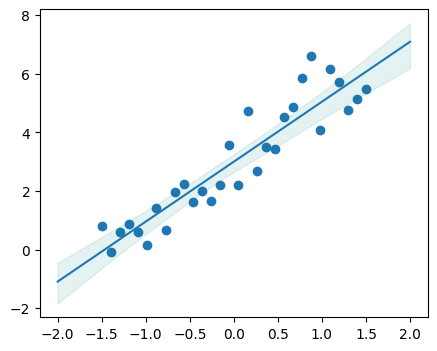

```python
from scipy.stats.mstats import mquantiles

p_seq = st.multivariate_normal.rvs(mean=p_avg, cov=p_cov, size=50)
x_base = np.linspace(-2, 2, 101)
y_hat = linear_fit(x_base, *p_avg)

plt.figure(figsize=(5,4))
plt.scatter(x, y_noisy)
plt.plot(x_base, y_hat)
y_hat = [linear_fit(x_base, *params) for params in p_seq]
y_hat = np.stack(y_hat)

p_low, p_top = mquantiles(y_hat, prob=[0.025, 0.975], axis=0)
plt.fill_between(x_base, p_low, p_top, alpha=0.1, color='teal')
plt.show()
```

Let's go back to logistic regression.

```python
def logistic_fit(xdata, r, k, y0=0.1):
    C = (k - y0) / y0
    return k / (1 + C * np.exp(-r * xdata))

p_avg, p_cov = curve_fit(logistic_fit, t_eval, y_hat_normal, p0=[1, 0.1])
```

```python
p_avg
```

```
array([9.90818327, 1.00970188])
```

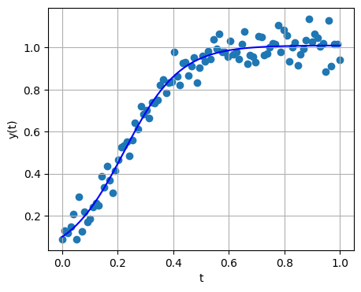

```python
y_fit = logistic_fit(t_eval, *p_avg)

plt.figure(figsize=(5,4))
plt.scatter(t_eval, y_hat_normal)
plt.plot(t_eval, y_fit, 'b')
plt.xlabel('t')
plt.ylabel('y(t)')
plt.grid(True)
plt.show()
```

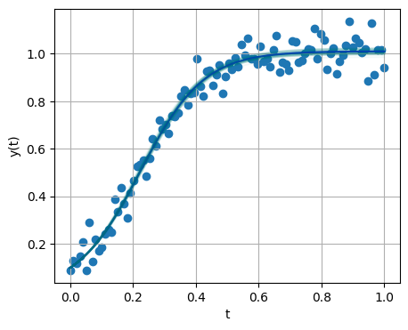

```python
p_seq = st.multivariate_normal.rvs(mean=p_avg, cov=p_cov, size=50)

plt.figure(figsize=(5,4))
plt.scatter(t_eval, y_hat_normal)
plt.plot(t_eval, y_fit, 'b')
plt.xlabel('t')
plt.ylabel('y(t)')
plt.grid(True)
for params in p_seq:
    y_hat_ = logistic_fit(t_eval, *params)
    plt.plot(t_eval, y_hat_, color='teal', alpha=0.05)
plt.show()
```

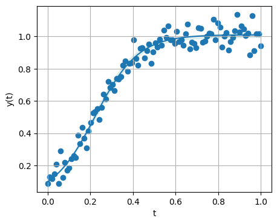

```python
p_seq = st.multivariate_normal.rvs(mean=p_avg, cov=p_cov, size=50)

plt.figure(figsize=(5,4))
plt.scatter(t_eval, y_hat_normal)
plt.plot(t_eval, y_fit)
plt.xlabel('t')
plt.ylabel('y(t)')
plt.grid(True)
y_hat_2 = [logistic_fit(t_eval, *params) for params in p_seq]
y_hat_2 = np.stack(y_hat_2)

p_low, p_top = mquantiles(y_hat_2, prob=[0.025, 0.975], axis=0)
plt.fill_between(t_eval, p_low, p_top, alpha=0.1, color='teal')
plt.show()
```

## Sensitivity analysis in machine learning

```python
import torch
import torch.nn as nn
import torch.optim as optim
from torchvision import datasets, transforms
```

```python
# MNIST dataset
transform = transforms.ToTensor()

train_loader = torch.utils.data.DataLoader(
    datasets.MNIST('.', train=True, download=True, transform=transform),
    batch_size=64,
    shuffle=True
)

test_loader = torch.utils.data.DataLoader(
    datasets.MNIST('.', train=False, transform=transform),
    batch_size=1
)
```

```python
# MLP
model = nn.Sequential(
    nn.Flatten(),
    nn.Linear(28*28, 64),
    nn.ReLU(),
    nn.Linear(64, 10)
)

# training
opt = optim.Adam(model.parameters(), lr=1e-3)
loss_fn = nn.CrossEntropyLoss()

for epoch in range(5):
    for x, y in train_loader:
        opt.zero_grad()
        out = model(x)
        loss = loss_fn(out, y)
        loss.backward()
        opt.step()
```

```python
# select a number
target_digit = 7

for x, y in test_loader:
    if y.item() == target_digit:
        break

x.requires_grad = True
```

```python
# predict class
out = model(x)
pred = out.argmax(dim=1)

loss = loss_fn(out, pred)
loss.backward()

grad = x.grad
```

```python
# image perturbation
epsilon = 0.2
x_mod = x + epsilon * grad.sign()
x_mod = torch.clamp(x_mod, 0, 1)
```

```python
# new prediction
out_mod = model(x_mod)
pred_mod = out_mod.argmax(dim=1)
```

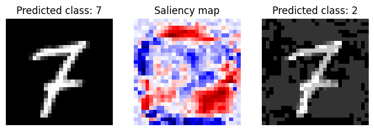

```python
plt.figure(figsize=(8,3))

plt.subplot(1,3,1)
plt.imshow(x.squeeze().detach(), cmap='gray')
plt.title(f"Predicted class: {pred.item()}")
plt.axis('off')

plt.subplot(1,3,2)
plt.imshow(grad.squeeze().detach(), cmap='seismic')
plt.title("Saliency map")
plt.axis('off')

plt.subplot(1,3,3)
plt.imshow(x_mod.squeeze().detach(), cmap='gray')
plt.title(f"Predicted class: {pred_mod.item()}")
plt.axis('off')

plt.show()
```

## Exercise

Consider the simple ODE shown as first example today:

$$ \frac{dy}{dt} = -ky $$

with parameter $k=0.4$ and initial condition $y_{0}=6$.

- Apply the two methods seen today to study the system.
- How would the results change if random samples were generated using the Van der Corput sequence?